# Section 3 - Logistic Regression versus Bayes Classifier

**Student Name: Xinyu Zhang**

**Student ID: 35486244**

### Q5-I

#### Load the breast cancer dataset

```python
from sklearn.datasets import load_breast_cancer
from sklearn.model_selection import train_test_split

# load the breast cancer dataset
breast_cancer = load_breast_cancer()
# Split into training set and test set, training set ratio 0.8
x_train, x_test, y_train, y_test = train_test_split(breast_cancer.data, breast_cancer.target, train_size=0.8, random_state=40)
# set the random seed
```

#### Define the BayesianClassifier model

```python
from scipy.stats import multivariate_normal

# define the BayesianClassifier model
class BayesianClassifier:

    def __init__(self, shared_cov=True, cond_ind=True):
        # shared_cov: whether all classes share the same covariance matrix
        self.shared_cov = shared_cov
        # cond_ind: whether Feature is the conditional independence
        self.cond_ind = cond_ind

    # train the model
    def fit(self, x, y):
        # find all classes and return class_counts
        self.classes_, class_counts = np.unique(y, return_counts=True)

        # define the mean matrix and covariance matrix
        self.n_, self.p_ = x.shape
        self.k_ = len(self.classes_)
        self.cond_means_ = np.zeros(shape=(self.k_, self.p_))
        self.cond_covs_ = np.zeros(shape=(self.k_, self.p_, self.p_))
        #  prior probability matrix of each class
        self.class_priors_ = class_counts / len(y)

        # Loop over classes, compute mean per feature
        for c in range(self.k_):
            c_rows = y == c   # selects all rows of class c
            self.cond_means_[c, :] = x[c_rows].mean(axis=0)  # selects all rows in x that correspond to that class c.

            # Skip when the number of categories samples is too small to avoid singular matrices
            if np.sum(c_rows) < 2:
                self.cond_covs_[c, :, :] = np.eye(self.p_) * 1e-6
                continue

            # check Feature conditional independence
            if self.cond_ind:
                # Add the stable term to prevent variance to 0
                var = x[c_rows].var(axis=0)
                var[var == 0] = 1e-6
                #  The calculated variance fills the diagonal of this matrix     var(axis=0): calculate the variance
                np.fill_diagonal(self.cond_covs_[c, :, :], var)
            else:
                # Add the stable term to prevent unstable covariance
                cov = np.cov(x[c_rows].T, bias=True)  #cov(x[c_rows].T, bias=True) : calculate the covariance of each feature.
                cov += 1e-6 * np.eye(cov.shape[0])
                self.cond_covs_[c, :, :] = cov


        # check and calculate shared covariance
        if self.shared_cov:
            shared_cov = (self.cond_covs_.T * self.class_priors_).T.sum(axis=0)
            self.cond_covs_[:] = shared_cov
        return self

    # predict probability
    def predict_proba(self, x):
        m, _ = x.shape
        cond_probs = np.zeros(shape=(m, self.k_))
        for c in range(self.k_):
            # calculate conditional_probs x\c
            cond_probs[:, c] = multivariate_normal.pdf(
                x, self.cond_means_[c], self.cond_covs_[c], allow_singular=True
            )
        # calculate marginal_probs  and avoid zero division
        marginal_probs = (cond_probs * self.class_priors_).sum(axis=1)+ 0.0001
        # calculate posterior probability p(c|x)
        probs = ((cond_probs * self.class_priors_).T / marginal_probs).T
        return probs

    def predict(self, x):
        return np.argmax(self.predict_proba(x), axis=1) # predict result is the max probability

    def decision_function(self, x):
        probs = self.predict_proba(x)
        # binary classification, return log odds
        # p(c=1|x) > p(c=0|x) or p(c=0|x) > p(c=1|x)
        if self.k_ == 2:
            return np.log(probs[:, 1] / probs[:, 0])
        else:
            res = np.zeros((len(x), self.k_))
            # more than two classes
            for c in range(self.k_):
                res[:, c] = np.log(probs[:, c] / (1 - probs[:, c]))
            return res
    # generate N data from class c Gaussian distribution.
    def generate(self, n, c, random_state=None):
        return multivariate_normal.rvs(
            self.cond_means_[c], self.cond_covs_[c], size=n, random_state=random_state)
```

#### Perform a training and test split (train size= 0.8) and Visualize the results of all models

```
train_01_losses [0.06999999999999995] ---->test_01_losses  [0.08695652173913049]
train_01_losses [0.06999999999999995, 0.040000000000000036] ---->test_01_losses  [0.08695652173913049, 0.02898550724637683]
train_01_losses [0.06999999999999995, 0.040000000000000036, 0.062000000000000055] ---->test_01_losses  [0.08695652173913049, 0.02898550724637683, 0.10144927536231885]
train_01_losses [0.06999999999999995, 0.040000000000000036, 0.062000000000000055, 0.04400000000000004] ---->test_01_losses  [0.08695652173913049, 0.02898550724637683, 0.10144927536231885, 0.02898550724637683]
```

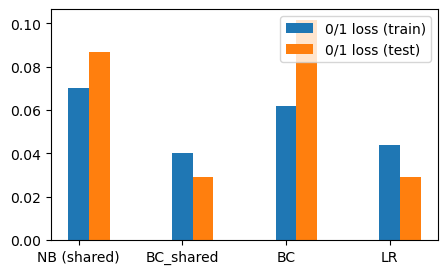

```python
from sklearn.metrics import zero_one_loss, log_loss
from sklearn.linear_model import LogisticRegression
from matplotlib import pyplot as plt

def plot_model_performances(models, model_names, x_train, y_train, x_test, y_test):
    train_01_losses = []
    train_log_losses = []
    test_01_losses = []
    test_log_losses = []

    for i, model in enumerate(models):
        train_01_losses.append(zero_one_loss(y_train, model.predict(x_train)))

        test_01_losses.append(zero_one_loss(y_test, model.predict(x_test)))

        print("train_01_losses", train_01_losses, "---->test_01_losses ", test_01_losses)

    xx = np.arange(len(models))
    bar_width = 1/(len(models)+1)
    group_width = len(models)*bar_width
    plt.bar(xx-group_width/2 + 2*bar_width, train_01_losses, width=bar_width, label='0/1 loss (train)')
    plt.bar(xx-group_width/2 + 3*bar_width, test_01_losses, width=bar_width, label='0/1 loss (test)')
    plt.xticks(xx, model_names)


nb_shared = BayesianClassifier(shared_cov=False, cond_ind=True).fit(x_train, y_train)
bc_shared = BayesianClassifier(shared_cov=True, cond_ind=False).fit(x_train, y_train)
bc = BayesianClassifier(shared_cov=False, cond_ind=False).fit(x_train, y_train)

lr = LogisticRegression(solver='lbfgs', max_iter=5000, random_state=0).fit(x_train, y_train)
#Logistic_regression.coef_

models = [nb_shared, bc_shared, bc, lr]
model_names = ['NB (shared)', 'BC_shared', 'BC', 'LR']

plt.subplots(1, 1, figsize=(5, 3))
plot_model_performances(models, model_names, x_train, y_train, x_test, y_test)
plt.legend()
plt.show()
```

### Q5-II

#### Test the performance for increasing training sizes and record training and test errors

```python
import numpy as np
from sklearn.model_selection import train_test_split
from sklearn.datasets import load_breast_cancer
from sklearn.linear_model import LogisticRegression
from sklearn.metrics import zero_one_loss

# define the array to save the result
#  [model_id, train_size, repeat_id, zero_one_train, zero_one_test]
results = []

# load the dataset
X, y = load_breast_cancer(return_X_y=True)

# Outer loop: different training set sizes
for n in range(5, 501, 5):
    # Inner loop: Repeat 10 times for each training set size
    for rep in range(10):
        X_train, X_test, y_train, y_test = train_test_split(
            X, y, train_size=n, shuffle=True, random_state=None
        )

        # train four models
        naiveb_shared = BayesianClassifier(shared_cov=False, cond_ind=True).fit(X_train, y_train)
        bc_shared = BayesianClassifier(shared_cov=True, cond_ind=False).fit(X_train, y_train)
        bc = BayesianClassifier(shared_cov=False, cond_ind=False).fit(X_train, y_train)
        # check sampling of training sets with less than two classes
        if len(set(y_train)) < 2:
            # If the training set has only one class, skip Logistic regression
            models = [naiveb_shared, bc_shared, bc]
            model_names = ['NB(shared)', 'BC_shared', 'BC']
        else:
            lr = LogisticRegression(solver="lbfgs", max_iter=4800).fit(X_train, y_train)
            models = [naiveb_shared, bc_shared, bc, lr]
            model_names = ['NB(shared)', 'BC_shared', 'BC', 'LR']

        # record the result of each model
        for mid, model in enumerate(models):
            train_err = zero_one_loss(y_train, model.predict(X_train))
            test_err  = zero_one_loss(y_test,  model.predict(X_test))
            results.append([mid, n, rep, train_err, test_err])

# turn to the NumPy array
results = np.array(results, dtype=float)
```

[output not shown]

### Q5-III

#### Create plots that compare the mean train and test performances of all models

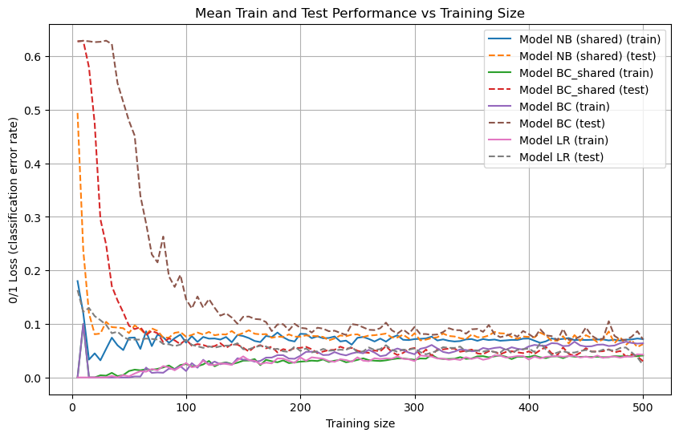

```python
import matplotlib.pyplot as plt

# get the model  index
model_ids = np.unique(results[:, 0]).astype(int)
# define the model_names
model_names = ['NB (shared)', 'BC_shared', 'BC', 'LR']

plt.figure(figsize=(10, 6))

for mid in model_ids:
    # Select data with the same model
    rows = results[results[:, 0] == mid]
    train_sizes = np.unique(rows[:, 1])

    train_means = []
    test_means = []

    # Calculate mean error for different training set sizes
    for ts in train_sizes:
        ts_rows = rows[rows[:, 1] == ts]
        train_means.append(np.mean(ts_rows[:, 3]))  # zero_one_train
        test_means.append(np.mean(ts_rows[:, 4]))   # zero_one_test

    # Plot training error & test error
    plt.plot(train_sizes, train_means, linestyle='-', label=f'Model {model_names[mid]} (train)')
    plt.plot(train_sizes, test_means, linestyle='--', label=f'Model {model_names[mid]} (test)')

plt.xlabel("Training size")
plt.ylabel("0/1 Loss (classification error rate)")
plt.title("Mean Train and Test Performance vs Training Size")
plt.legend()
plt.grid(True)
plt.show()
```

### Q5-IV

**Q5-IV-a**

As can be seen from the figure, **as the training data increases**, the **training performance** of each algorithm will **gradually decrease**, the **test performance** will gradually **increase** and eventually the performance will tend to be **stable**.

**Q5-IV-b**

As can be seen from the figure, when the training set is small, the performance of **the LogisticRegression model test is better**, and when the training set is large, the performance of the **BayesianClassifier model with shared covariance is better**.

**Q5-IV-c**

Because LogisticRegression is a simple model, while the Bayesian Classifier model with shared covariance is more complex, they must balance**bias and variance** to achieve better test set performance and **prevent overfitting**.

Therefore, the simpler LogisticRegression model can achieve good and stable performance with only a small training set. Similarly, the more complex Bayesian Classifier model **requires a large training set to achieve good performance and prevent overfitting due to a small training set**.